# Laboratory of Biostatistics Assessment

Group nº3 - Carolina Santos nº49286, Filipe Santos nº55142 & Hugo Anjos nº49209

28 de Dezembro de 2019

# Objectives

The main objective is to **explore Liver and Intrahepatic Bile Ducts Cancer mortality geographical and time trends** for the following countries:

- `Austria`
- `Cyprus`
- `Germany`
- `Malta`
- `Portugal`
- `European Union`

To do so, we will answer the following questions, always **treating males and females separately**:

# Reading the Data

```r
data <- fread(here("CancerMortalityEU.csv"), header = TRUE, check.names = TRUE)
popdt <- fread("PopulationEU.csv", header = TRUE, check.names=TRUE)
```

# Data Limitations

By taking a quick look at the data sets we can observe that there is some missing data for some countries and for the year 2017, in specific, there is no data regarding the cancer for the countries of Portugal and Malta.

Also, there are some inherent limitations to the data in the sense that, the change registered in the mortality rate, from year to year, may be due to:

- Improvements to the detection methods for this kind of cancer
- An increase in the portion of the population being tested and diagnosed

Differences between countries might bue due to these limitations.

# Data Tidying

## Cancer Data:

```r
# Removing unnecessary columns
cancro <- data[CancerSite %in% "Liver and Intrahepatic Bile Ducts"]

cancro[, c("CancerSite", "Cause", "ageStart", "ageLabel"):=NULL]
setnames(cancro, "ageGroup", "Age")

# Melt of tha cancer data

cancer.new <- melt(cancro,
                   id.vars = c("Country","Age"),
                   variable.name = "all",
                   value.name = "Deaths")

cancer.new[, `:=` (Year=as.numeric(gsub("[^[:digit:].]",
                            "", all)))]

cancer.new[, Sex:=as.character(unglue_vec(all,"{x}_{y}",var="x"))]

cancer.new[, .N, by="Year"]
cancer.new[, .N, by="Sex"]
cancer.new[, all:=NULL]
setcolorder(cancer.new, c("Country","Age","Sex","Year","Deaths"))

#Removing Na
cancer.new <- na.omit(cancer.new)

# Criação do EU

cancer.EU <- cancer.new[, .(Country = "European Union", Deaths = sum(Deaths, na.rm = TRUE)), by = .(Year, Sex, Age)]
setcolorder(cancer.EU, c("Country","Age","Sex","Year","Deaths"))
cancer.liver <- rbind(cancer.new,cancer.EU)

# Criação do all

allAge <- cancer.liver[, .(Age = "All", Deaths = sum(Deaths, na.rm = TRUE)), by = .(Country, Year, Sex)]
setcolorder(allAge, c("Country", "Sex", "Age", "Year", "Deaths"))
cancer.liver <- rbind(cancer.liver,allAge)

# Selecting the important countries

cancer.liver <- cancer.liver[Country %in% c("Austria", "Cyprus", "Germany", "Malta", "Portugal", "European Union")
                             ][order(Year, Country, Sex)]
cancer.liver
```

## Population Data:

```r
# Importing data
library(data.table)
popdt <- fread("PopulationEU.csv",
               header = TRUE, check.names=TRUE)

# Removing ageStart and ageLabel columns
popdt[, c("ageStart","ageLabel","X2000","X2001","X2002","X2003","X2004","X2005","X2006","X2007","X2008","X2009","X2010","X2018"):=NULL]

# Renaming ageGroup column to Age
setnames(popdt, c("ageGroup"),
                c("Age"))

# Morphing to long format
popT <- melt(popdt,
            id.vars = c("Country", "Sex", "Age"),
            measure = patterns("^X"),
            variable.name = "YearX",
            value.name = c("Population"),
            na.rm = TRUE)

# Year as numeric, removing YearX
popT[, `:=` (Year=as.numeric(gsub("[^[:digit:].]",
                            "", YearX)))][, YearX := NULL]
setcolorder(popT, c("Country", "Sex", "Age", "Year", "Population"))

# Removing rows for total population data

#Seeing as we are treating females and males differently, the rows regarding total population info will not be used and should be removed.
popT <- popT[Sex != "Total"]

# Creating European Union as "Country"
#EU's population is the sum of the populations for each country, by year and age group

popEU <- popT[, .(Population = sum(Population, na.rm = TRUE)), by = .(Year, Sex, Age)][, Country := "European Union"]
setcolorder(popEU, c("Country", "Sex", "Age", "Year", "Population"))
pop <- rbind(popT, popEU)
pop <- pop[order(Year, Country)]

# Creating age group category "All", combining all ages
allAge <- pop[, .(Age = "All", Population = sum(Population, na.rm = TRUE)), by = .(Country, Year, Sex)]
setcolorder(allAge, c("Country", "Sex", "Age", "Year", "Population"))
allAge <- allAge[order(Year, Country)]

# Merging pop and allAge
pop <- rbind(pop, allAge)
pop <- pop[order(Year, Country, Sex)]

# Selecting only the countries in study
popF <- pop[Country %in% c("Austria", "Cyprus", "Germany", "Malta", "Portugal", "European Union")]
popF <- popF[order(Year, Country)]

popF
```

## Merging the two data sets:

```r
data.f <- cancer.liver[popF, on=c("Country","Age","Sex","Year")]
data.f[, mrate := round(100000*Deaths/Population,2)]
data.f[Age %in% "All"][Sex %in% "Females"][, sum(Deaths, na.rm = TRUE), by=Country]
data.f
```

## Preparing the Data for the second question:

```r
data.2016 <- data.f[Year %in% "2016"][Deaths != "NA"]
data.2016$Age <- as.factor(data.2016$Age)
levels(data.2016$Age)
data.2016$Age <- factor(data.2016$Age, levels(data.2016$Age)[c(1,10,2:9,11:19)])
```

## Preparing the data for the third question:

```r
# For the male population
data.diff.M <- data.f[Year != 2017][Year != 2011 & Sex %in% "Males" & Age %in% "All"]
data.diff.M[,per := ((data.diff.M$mrate - data.f[Year %in% 2011 & Sex %in% "Males" & Age %in% "All"]$mrate )/data.f[Year %in% 2011 & Sex %in% "Males" & Age %in% "All"]$mrate*100)]
diff.M <- data.diff.M[, DiffCountry := sprintf("%3.1f%%", per)][, .(Country, Year, DiffCountry)]
diff.Males <- dcast(diff.M, Year ~ Country, value.var = "DiffCountry" )

# For the female population

data.diff.F <- data.f[Year != 2017][Year != 2011 & Sex %in% "Females" & Age %in% "All"]
data.diff.F[,per := ((data.diff.F$mrate - data.f[Year %in% 2011 & Sex %in% "Females" & Age %in% "All"]$mrate )/data.f[Year %in% 2011 & Sex %in% "Females" & Age %in% "All"]$mrate*100)]
diff.F <- data.diff.F[, DiffCountry := sprintf("%3.1f%%", per)][, .(Country, Year, DiffCountry)]
diff.Females <- dcast(diff.F, Year ~ Country, value.var = "DiffCountry" )
```

## Preparing the data for the fourth question:

```r
# Reading all cancer data
allCancer <- fread("CancerMortalityEU.csv",
               header = TRUE, check.names=TRUE)

# Removing superfluous columns
allCancer[, c("Cause", "ageStart", "ageLabel"):=NULL]
setnames(allCancer, "ageGroup", "Age")

# Converting table to long format
allCancer <- melt(allCancer,
                  id.vars = c("Country","Age","CancerSite"),
                  variable.name = "Sex+Year",
                  value.name = "Deaths")

# Separating Year and Sex data
allCancer[, `:=` (Year=as.numeric(gsub("[^[:digit:].]",
                            "", `Sex+Year`)))]
allCancer[, Sex:=as.character(unglue_vec(`Sex+Year`,"{x}_{y}",var="x"))]
allCancer[, "Sex+Year":=NULL]
setcolorder(allCancer, c("Country","Year","Sex","Age","CancerSite","Deaths"))

# Creating EU as a country
cancerEU <- allCancer[, .(Country = "European Union", Deaths = sum(Deaths)), by = .(Year, Sex, Age, CancerSite)]
setcolorder(cancerEU, c("Country","Year","Sex","Age","CancerSite","Deaths"))
allCancer <- rbind(allCancer, cancerEU)

# Creating All ages rows
allAge <- allCancer[, .(Age = "All", Deaths = sum(Deaths, na.rm = TRUE)), by = .(Country, Year, Sex, CancerSite)]
setcolorder(allAge, c("Country","Year","Sex","Age","CancerSite","Deaths"))
allCancer <- rbind(allCancer, allAge)

# Selecting the important countries
allCancer <- allCancer[Country %in% c("Austria", "Cyprus", "Germany", "Malta", "Portugal", "European Union")
                             ][order(Year, Country)]

# Removing "All Cancer" from CancerSite
allCancer <- allCancer[CancerSite != "All Cancers"]

allCancer
```

# Questions

## First Question

> What are the time trends in the mortality rates between countries for all age groups (“All”) combined?

> How do they compare with the European Union overall?

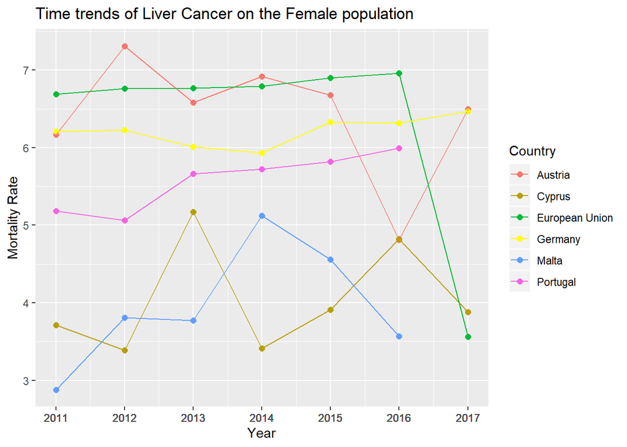

```r
p <- data.f[Age %in% "All"][Sex %in% "Females"][Country != "Germany"] %>%
ggplot(aes(Year,mrate, group=Country, colour = Country)) +
    geom_point(size=2) +
    geom_line() +
    ggtitle("Time trends of Liver Cancer on the Female population") +
    ylab("Mortality Rate") +
    scale_x_continuous(labels=data.f[,Year], breaks = data.f[,Year])+
    geom_point(data = data.f[Age %in% "All"][Sex %in% "Females"][Country %in% "Germany"], aes(Year, mrate, group= Country), colour = "yellow")+
    geom_line(data = data.f[Age %in% "All"][Sex %in% "Females"][Country %in% "Germany"], aes(Year, mrate, group= Country), colour = "yellow")

ggplot_build(p)$data

data.f[Age %in% "All"][Sex %in% "Females"] %>%
ggplot(aes(Year,mrate, group=Country, colour = Country)) +
    geom_point(size=2) +
    geom_line() +
    ggtitle("Time trends of Liver Cancer on the Female population") +
    ylab("Mortality Rate") +
    scale_x_continuous(labels=data.f[,Year], breaks = data.f[,Year])+
    scale_colour_manual(labels = c("Austria", "Cyprus", "European Union", "Germany", "Malta", "Portugal"), values = c("#F8766D", "#B79F00", "#00BA38", "yellow", "#619CFF", "#F564E3"))
```

### Interpretation

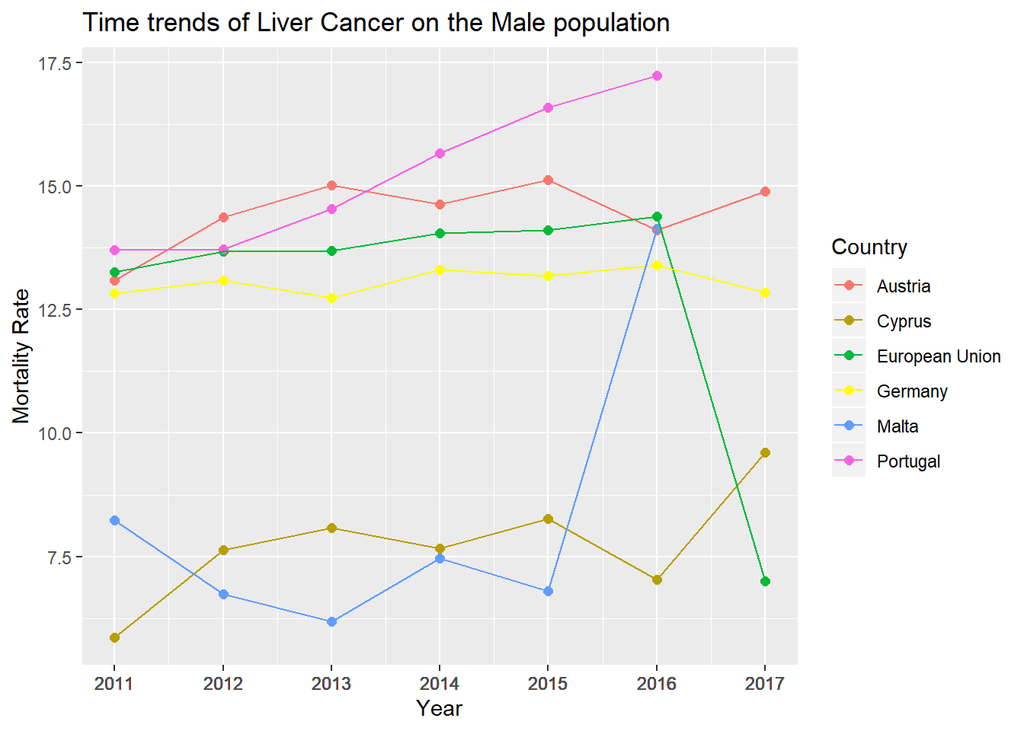

```r
data.f[Age %in% "All"][Sex %in% "Males"] %>%
ggplot(aes(Year,mrate, group=Country, colour = Country))+
    geom_point(size=2)+
    geom_line()+
    ggtitle("Time trends of Liver Cancer on the Male population")+
    ylab("Mortality Rate") +
    scale_x_continuous(labels=data.f[,Year], breaks = data.f[,Year])+
    scale_colour_manual(labels = c("Austria", "Cyprus", "European Union", "Germany", "Malta", "Portugal"), values = c("#F8766D", "#B79F00", "#00BA38", "yellow", "#619CFF", "#F564E3"))
```

## Second Question

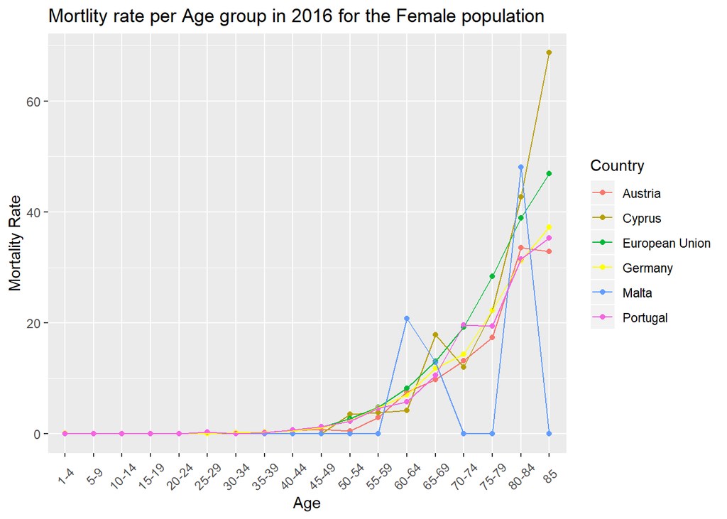

```r
data.2016[Sex %in% "Females"][Age != "All"] %>%
ggplot(aes(Age,mrate, group=Country, colour=Country))+
    geom_point()+
    geom_line()+
    theme(axis.text.x = element_text(angle=45, vjust = 0.5))+
    ggtitle("Mortlity rate per Age group in 2016 for the Female population")+
    ylab("Mortality Rate")+
    scale_colour_manual(labels = c("Austria", "Cyprus", "European Union", "Germany", "Malta", "Portugal"), values = c("#F8766D", "#B79F00", "#00BA38", "yellow", "#619CFF", "#F564E3"))
```

### Interpretation

- In every country (except in Malta which is a lot harder to describe) we see a general increase on the mortality rate as the age class increases (starting in the 35 to 39 age class)
- Contrary to the other countries (which always increase), Malta’s mortality rate oscilates a lot between the classes 55-60 and 85, where it ends with a 0 mortality rate
- The first Age classes (until the 35-39 age class) show zero to low mortality rate for this type of cancer on the Female population
- The trend observed here is that the older population (from the age of 50 foward) is more susceptible to die due to this kind of cance. Germany, Austria, Portugal, Malta and Cyprus have a lower mortality rate when compared to the mortality rate of the European Union
  - Malta only has a higher mortatlity rate than the European Union in the classes of 60-64 and 80-84
  - Cyprus only has a higher mortality rate than the European Union in the classes of 50-54, 65-69, 80-84 and 85

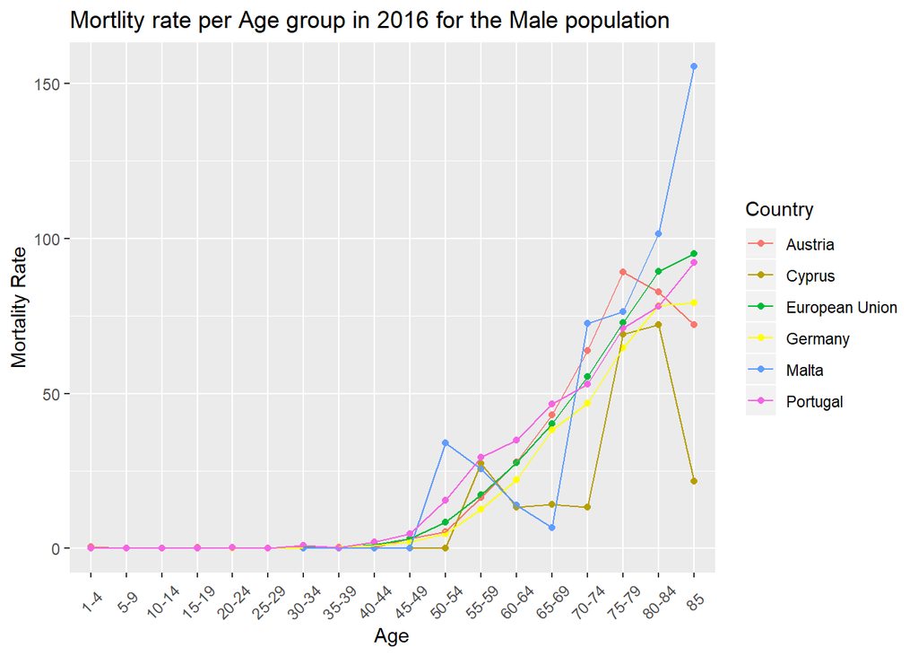

```r
data.2016[Sex %in% "Males"][Age != "All"] %>%
ggplot(aes(Age,mrate, group=Country, colour=Country))+
    geom_point()+
    geom_line()+
    theme(axis.text.x = element_text(angle=45, vjust = 0.5))+
    ggtitle("Mortlity rate per Age group in 2016 for the Male population")+
    ylab("Mortality Rate") +
    scale_x_discrete(labels=data.f[,Age], breaks = data.f[,Age])+
    scale_colour_manual(labels = c("Austria", "Cyprus", "European Union", "Germany", "Malta", "Portugal"), values = c("#F8766D", "#B79F00", "#00BA38", "yellow", "#619CFF", "#F564E3"))
```